## Loading and preprocessing the data

The data was read from the “activity.csv” file located in the working directory

```r
activity_data <- read.csv("activity.csv")
```

## What is mean total number of steps taken per day?

In order to look at the average number of steps taken each day, first we aggregate the total steps taken per day, then plot this data as a histogram:

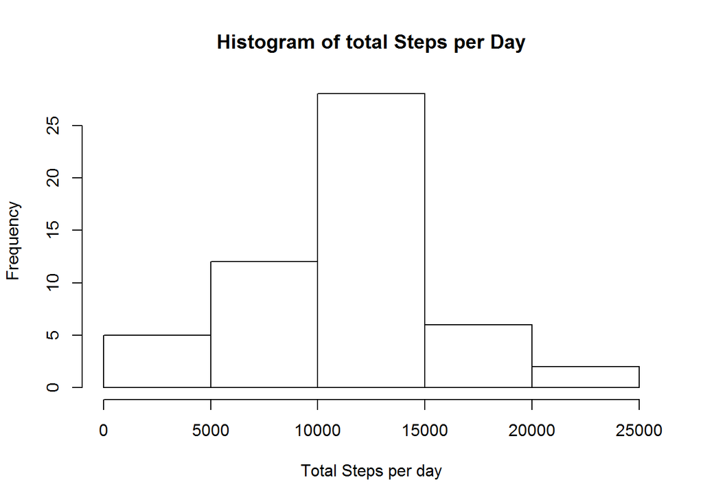

```r
##aggregate total steps by day
activity_agg <-aggregate(activity_data$steps, by = list(activity_data$date), sum)
##create histogram of steps per day
hist(activity_agg$x, main="Histogram of total Steps per Day",xlab="Total Steps per day")
```

Then we can calculate the mean and median of total stpes per day:

```r
mean_steps <- mean(activity_agg$x, na.rm=TRUE)
median_steps <- median(activity_agg$x, na.rm=TRUE)
```

This gives us a mean of 1.076618910^{4} and a median of 10765.

## What is the average daily activity pattern?

To examine this, we can make a plot to look at the number of steps taken per 5-mintue interval.

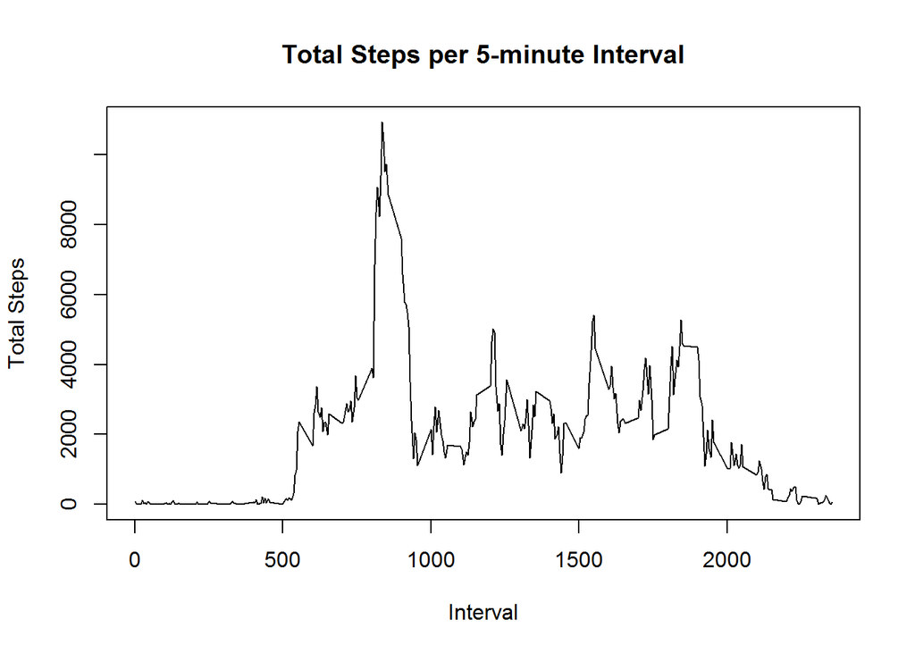

```r
##average daily activity patterns (5-minute intervals)
activity_int <- aggregate(activity_data$steps, by = list(activity_data$interval), sum, na.rm = TRUE)
plot(activity_int$Group.1, activity_int$x, type = "l",main="Total Steps per 5-minute Interval",xlab = "Interval",ylab="Total Steps")
```

The interval with the highest number of steps can be calculated:

```r
highint <-activity_int$Group.1[which.max(activity_int$x)]
high_steps <- max(activity_int$x)
```

So interval 835 had the most total steps with 10927 total steps.

## Imputing missing values

To input missing values, first we count the total number of missing values

```r
miss_val <- sum(is.na(activity_data$steps))
```

So there are 2304 missing values.

Next, the mean of steps taken per each interval is calculated.

```r
int_means <- aggregate(activity_data$steps, by = list(activity_data$interval), mean, na.rm = TRUE)
```

This is then appended onto the original data matched by intervals, then the NA values in the steps column are replaced by the corresponding means, creating a new dataset with all missing values replaced by the overall mean for that interval.

```r
newdata <- merge(activity_data, int_means, by.x = 3, by.y = 1)
newdata$steps[is.na(newdata$steps)] <- newdata$x[is.na(newdata$steps)]
```

We can then look at the same histogram used earlier with the NA’s removed

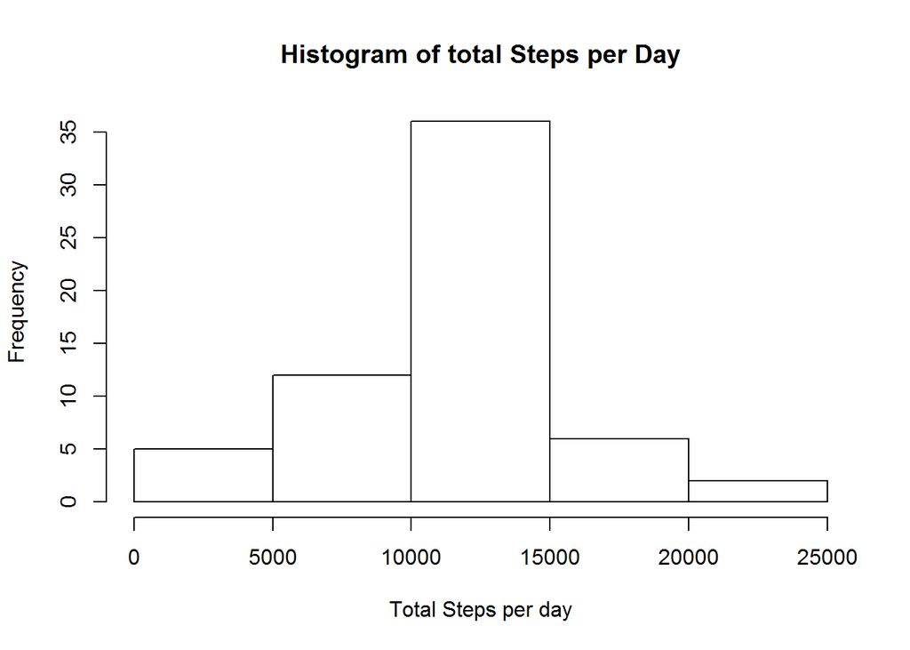

```r
##create histogram of steps per day with NA's removed
new_agg <-aggregate(newdata$steps, by = list(newdata$date), sum)
hist(new_agg$x, main="Histogram of total Steps per Day",xlab="Total Steps per day")
```

This shows that the replaced values did not have a significant effect on the distribution.

We calculate the updated mean and median.

```r
new_mean_steps <- mean(new_agg$x)
new_median_steps <- median(new_agg$x)
```

This gives us a mean of 1.076618910^{4} and a median of 1.076618910^{4} compared to our earlier mean and median of 1.076618910^{4} and 10765 respectively.

## Are there differences in activity patterns between weekdays and weekends?

To examine potential differences in daily activity between weekends and weekdays, first we must create an indicator in the data to differentiate between weekends and weekdays.

```r
##create factor variable for weekdays and weekends
days <- weekdays(as.Date(newdata$date, format = "%Y-%m-%d"))
weekend <- c('Saturday', 'Sunday')
days2 <- c('Weekday', 'Weekend')[days %in% weekend+1L]
wewd_data <-cbind(newdata,days2)
wewd_data$x <- NULL
```

Then we calculate the means for each interval for both weekends and weekdays.

```r
##divide Weekends and Weekdays and find means for each interval
we_data <- wewd_data[wewd_data$days2=="Weekend",]
wd_data <- wewd_data[wewd_data$days2=="Weekday",]
we_agg <- aggregate(we_data$steps, by = list(we_data$interval), mean)
wd_agg <- aggregate(wd_data$steps, by = list(wd_data$interval), mean)
##Combine weekend and weekday data into one frame
we_agg2 <- cbind(we_agg,"weekend")
wd_agg2 <- cbind(wd_agg,"weekday")
names(we_agg2)[3]<-"day"
names(wd_agg2)[3]<-"day"
split_agg <- rbind(we_agg2,wd_agg2)
```

We can plot this data using the lattice system to compare the activity patterns.

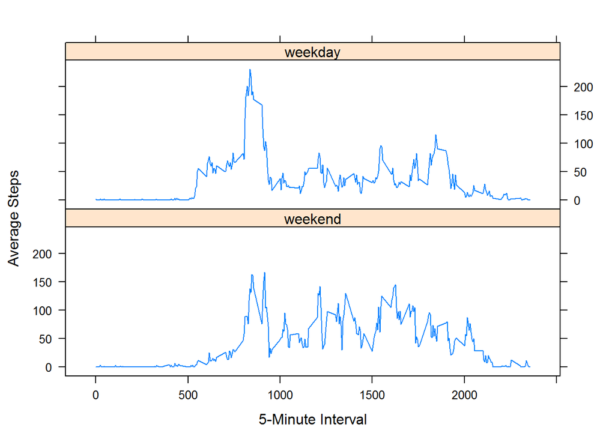

```r
##plot average steps per interval Weekday vs. weekend
library(lattice)
xyplot(x~Group.1|day, split_agg, type="l", layout = c(1,2), xlab = "5-Minute Interval", ylab="Average Steps")
```

This shows us a higher morning peak for weekdays, but higher levels of activity throughout the day during weekends.